# 貝氏方法 (Bayes)

JianKai Wang (https://sophia.ddns.net/)

2018年4月2日

貝氏理論基礎為**條件機率**，說明在一條件下(或稱先驗機率, prior probability)，一事件發生的機率(又稱後驗概率, posterior probability)。條件機率概念如下，若 A, B 為樣本空間 $S$ 中的二事件，且 $P(A) > 0$，則在給定 A 發生下，B 發生之條件機率以 $P(B|A)$ 表示，並定義為

$$P(B|A) = \frac{P(A \cap B)}{P(A)}, \\
P(A \cap B) = P(B|A)*P(A) ... (1)$$

以此類推 $P(A \cap B)$ 亦可由在 $P(B) > 0$ 的條件下推算而得 $P(A \cap B) = P(A|B)*P(B) ... (2)$。而若整理上述 $(1)$ 及 $(2)$ 公式，則可得下列結論:

$$P(A \cap B) = P(B|A)*P(A) = P(A|B)*P(B)\\
\Rightarrow P(B|A) = \frac{P(A|B)*P(B)}{P(A)}$$

而**貝氏理論**可視為條件機率的延伸說明。 假設一隨機現象的樣本空間為 $S$，若事件 $A_1, A_2, A_3, ..., A_n$ 滿足底下條件

1. $A_1, A_2, A_3, ..., A_n$ 兩兩互斥
2. $A_1 \cup A_2 \cup A_3, ..., \cup A_n = S$

則稱事件 $A_1, A_2, A_3, ..., A_n$ 是樣本空間 $S$ 的一個分割。而貝氏定理擁有 **分割定理** 與 **貝氏定理** 兩個定理。

- 分割原理: 設 $A_1, A_2, A_3, ..., A_n$ 是樣本空間 $S$ 的一個分割，其中 $P(A_k) > 0,k=1,2,3,...,n$，則對任意事件 $E$，恆有

$$P(E) = P(A_1)*P(E|A_1) + P(A_2)*P(E|A_2) + P(A_3)*P(E|A_3) + ... + + P(A_n)*P(E|A_n)\\
= \sum_{k=1}^nP(A_k)*P(E | A_k)$$

特性，可以透過圖像化方式理解，如下：

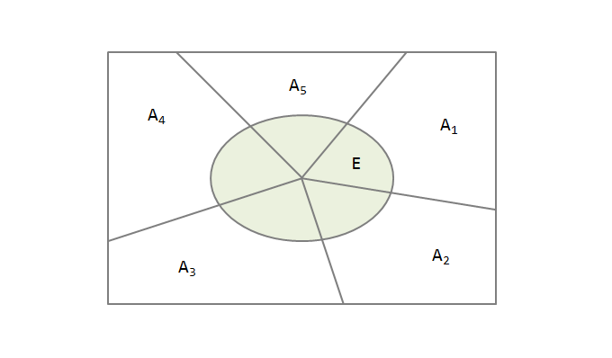

$A_1, A_2, A_3, ..., A_n$ 是樣本空間 $S$ 的一個分割，$E = (A_1 \cap E) \cup (A_2 \cap E) \cup (A_3 \cap E) \cup ... \cup (A_n \cap E)$ 且 $(A_1 \cap E),(A_2 \cap E), ... ,(A_n \cap E) 兩兩互斥$，故

$$P(E) = P(A_1 \cap E) + P(A_2 \cap E) + ... + P(A_n \cap E)\\
= P(A_1)*P(E|A_1) + P(A_2)*P(E|A_2) + ... + + P(A_n)*P(E|A_n)$$

- 貝氏定理:設 $A_1, A_2, A_3, ..., A_n$ 是樣本空間 $S$ 的一個分割，其中 $P(A_k) > 0,k=1,2,3,...,n$。若 $E$ 是一事件，且 $P(E) > 0$，則

$$P(A_i|E) = \frac{P(A_i \cap E)}{P(E)} = \frac{P(A_i)*P(E|A_i)}{\sum_{k=1}^nP(A_k)*P(E|A_k)},i=1,2,...,n$$

其中 $A_1, A_2, A_3, ..., A_n$ 又可稱為先驗機率。

## 貝氏分類器

### 使用套件

R 中有數個實作出貝氏理論的套件，如 naiveBayes{e1071} 與 NaiveBayes{klaR} 等都是實作函式。而 naiveBayes{e1071} 是以類別資料為對象，而 NaiveBayes{klaR} 則可以用連續資料作為分析對象。

### 安裝套件

貝氏方法可以用於分類，故又稱貝氏分類器，可使用來自於 **e1071** 的套件中 **naiveBayes** 函式來實現。使用的資料集來自於 **mlbench** 套件。

```r
packageName <- c("e1071","mlbench")
for(i in 1:length(packageName)) {
  if(!(packageName[i] %in% rownames(installed.packages()))) {
    install.packages(packageName[i])
  }
}
lapply(packageName, require, character.only = TRUE)
```

```
## [[1]]
## [1] TRUE
##
## [[2]]
## [1] TRUE
```

### 資料準備

使用來自於 **mlbench** 套件中的資料 **HouseVotes84**。其中 class 為輸出變數(要預測的變數)，而其他變數為輸入變數(特徵值)。

```r
data("HouseVotes84", package="mlbench")
head(HouseVotes84, 10)
```

```
##         Class   V1 V2 V3   V4   V5 V6 V7 V8 V9 V10  V11  V12  V13 V14  V15
## 1  republican    n  y  n    y    y  y  n  n  n   y <NA>    y    y   y    n
## 2  republican    n  y  n    y    y  y  n  n  n   n    n    y    y   y    n
## 3    democrat <NA>  y  y <NA>    y  y  n  n  n   n    y    n    y   y    n
## 4    democrat    n  y  y    n <NA>  y  n  n  n   n    y    n    y   n    n
## 5    democrat    y  y  y    n    y  y  n  n  n   n    y <NA>    y   y    y
## 6    democrat    n  y  y    n    y  y  n  n  n   n    n    n    y   y    y
## 7    democrat    n  y  n    y    y  y  n  n  n   n    n    n <NA>   y    y
## 8  republican    n  y  n    y    y  y  n  n  n   n    n    n    y   y <NA>
## 9  republican    n  y  n    y    y  y  n  n  n   n    n    y    y   y    n
## 10   democrat    y  y  y    n    n  n  y  y  y   n    n    n    n   n <NA>
##     V16
## 1     y
## 2  <NA>
## 3     n
## 4     y
## 5     y
## 6     y
## 7     y
## 8     y
## 9     y
## 10 <NA>
```

### 建立貝氏分類器模型

```r
# the prototype of naiveBayes
# formula: 公式, 如 Class ~ x1 + x2 等或 Class ~ . 等
# laplace: 使用 laplace 平滑調整
# type: 輸出結果內容，class (分類結果)與 raw(機率)
# threshold: 最小閥值
# na.action: NA 值處理方式
naiveBayes(
  formula, data,
  laplace = 0, type = c("class","raw"), threshold = 0.001,
  na.action = na.pass, ...)
```

```r
set.seed(123)
traning_idx = sample(1:nrow(HouseVotes84),floor(nrow(HouseVotes84)*2/3))
traning_data = HouseVotes84[traning_idx, ]
testing_data = HouseVotes84[-traning_idx, ]
model = naiveBayes(Class ~ ., data=traning_data)
model
```

```
##
## Naive Bayes Classifier for Discrete Predictors
##
## Call:
## naiveBayes.default(x = X, y = Y, laplace = laplace)
##
## A-priori probabilities:
## Y
##   democrat republican
##  0.5827586  0.4172414
##
## Conditional probabilities:
##             V1
## Y                    n         y
##   democrat   0.4024390 0.5975610
##   republican 0.7966102 0.2033898
##
##             V2
## Y                    n         y
##   democrat   0.5102041 0.4897959
##   republican 0.5047619 0.4952381
##
##             V3
## Y                    n         y
##   democrat   0.1333333 0.8666667
##   republican 0.8644068 0.1355932
##
##             V4
## Y                     n          y
##   democrat   0.96987952 0.03012048
##   republican 0.01680672 0.98319328
##
##             V5
## Y                     n          y
##   democrat   0.78395062 0.21604938
##   republican 0.06666667 0.93333333
##
##             V6
## Y                    n         y
##   democrat   0.5243902 0.4756098
```

[output cut: 36 more lines]

```
##
##             V14
## Y                     n          y
##   democrat   0.63803681 0.36196319
##   republican 0.01694915 0.98305085
##
##             V15
## Y                     n          y
##   democrat   0.36477987 0.63522013
##   republican 0.92857143 0.07142857
##
##             V16
## Y                     n          y
##   democrat   0.06666667 0.93333333
##   republican 0.29906542 0.70093458
```

### 預測資料

- 預測資料

```r
pred <- predict(model, testing_data[,-1])
pred
```

```
##   [1] republican democrat   democrat   republican republican democrat
##   [7] democrat   republican republican democrat   republican democrat
##  [13] democrat   democrat   democrat   democrat   democrat   democrat
##  [19] republican democrat   democrat   democrat   republican democrat
##  [25] republican republican republican republican democrat   democrat
##  [31] democrat   democrat   republican democrat   democrat   republican
##  [37] republican democrat   democrat   democrat   democrat   democrat
##  [43] republican democrat   republican democrat   democrat   republican
##  [49] democrat   democrat   republican republican democrat   republican
##  [55] republican republican republican democrat   republican democrat
##  [61] democrat   republican democrat   democrat   democrat   democrat
##  [67] democrat   democrat   democrat   republican democrat   democrat
##  [73] republican democrat   republican democrat   democrat   republican
##  [79] democrat   republican democrat   democrat   democrat   republican
##  [85] democrat   democrat   democrat   democrat   democrat   democrat
##  [91] democrat   democrat   republican republican republican democrat
##  [97] democrat   democrat   democrat   democrat   republican republican
## [103] democrat   republican democrat   democrat   republican republican
## [109] republican democrat   democrat   democrat   democrat   democrat
## [115] republican democrat   republican republican republican democrat
## [121] republican democrat   republican democrat   democrat   republican
## [127] democrat   democrat   republican republican democrat   democrat
## [133] republican republican republican democrat   republican republican
## [139] republican democrat   republican democrat   democrat   democrat
## [145] republican
## Levels: democrat republican
```

- 顯示機率計算的結果

```r
predict(model, testing_data[1:10,-1], type="raw")
```

```
##           democrat   republican
##  [1,] 5.993665e-03 9.940063e-01
##  [2,] 9.531394e-01 4.686062e-02
##  [3,] 7.394944e-01 2.605056e-01
##  [4,] 1.133874e-04 9.998866e-01
##  [5,] 4.089389e-06 9.999959e-01
##  [6,] 1.000000e+00 2.123986e-08
##  [7,] 1.000000e+00 1.059360e-09
##  [8,] 2.324822e-07 9.999998e-01
##  [9,] 5.552942e-08 9.999999e-01
## [10,] 9.999938e-01 6.168911e-06
```

### 建立預測資料的交叉矩陣

```r
table(pred, testing_data$Class)
```

```
##
## pred         democrat republican
##   democrat         85          2
##   republican       13         45
```

## 貝氏網路

貝氏網路(又稱信念網路, 有向無環圖模型等)，是一種機率圖型模型，藉由有向無環圖(directed acyclic graphs, or DAGs)中得知一組隨機變數($X_1, X_2, X_3, ..., X_n$)及其 n 組條件機率分配(conditional probability distributions, or CPDs)的性質。舉例而言，貝氏網路可用來表示疾病和相關症狀間的機率關係。

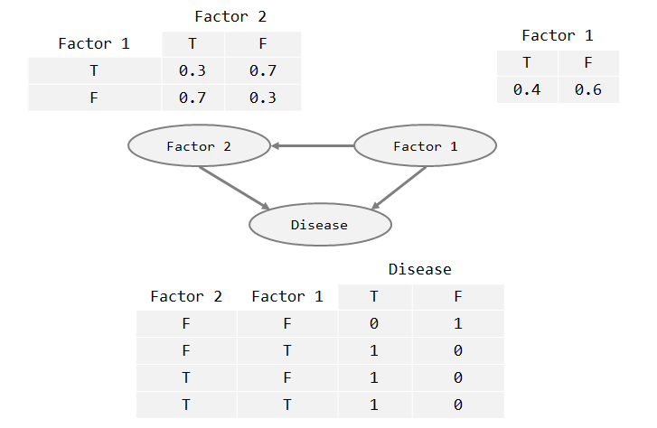

舉上例而言，假設有兩種因子($F1$,$F2$)會導致疾病($D$)發生，但第二個因子會受到第一個因子的影響，就每個因子而言，就只有兩種可能結果:導致(*T*)與不導致(*F*)，則此貝氏網路(如上圖)之聯合機率可表示成：

解貝氏網路是相當複雜的計算，一般而言可以分成底下兩類：

- 精準推論
  - 列舉推理
  - 變數消去法
- 隨機推論(蒙地卡羅方法)
  - 直接取樣
  - 拒絕取樣
  - 概似取樣
  - 馬可夫鏈蒙地卡羅 (Markov chain Monte Carlo, MCMC)

### 安裝套件

貝氏網路可透過 **deal** 來實現，包含如 **network** 等重要函式。

```r
packageName <- c("deal")
for(i in 1:length(packageName)) {
  if(!(packageName[i] %in% rownames(installed.packages()))) {
    install.packages(packageName[i])
  }
}
lapply(packageName, require, character.only = TRUE)
```

```
## [[1]]
## [1] TRUE
```

### 建構網路常用函式介紹

| 函式 | 說明 |
| --- | --- |
| network | 建構網路 |
| localprob | 先驗機率 |
| autosearch | 自動搜索網路 |
| insert | 加入一個有向線(箭頭表示)至網路中 |
| remover | 於網路中移除一個有向線 |
| jointprior | 計算先驗聯合機率分布 |
| learn | 於局部機率分布中估計參數 |
| heuristic | 透過 greedy search 嘗試建立網路，以提升網路分數 |
| getnetwork | 取得建構網路的資料資訊 |
| savenet | 儲存網路 |
| modelstring | 取得建構後的網路資訊 |
| makenw | 創建網路家族譜 |
| gettable | 取得所有的子網路資訊 |
| drawnetwork | 透過互動方式讓使用者建立貝式網路 |
| maketrylist | 為了更快速學習，trylist 作為查找預先定義的父節點 |
| nwfsort | 對網路族作分析，並依網路與得分進行排序 |
| perturb | 對網路做隨機更改，如新增/修改/刪除一條有向線等 |
| score | 網路的分數 |

### 建構網路 (Network)

- 資料準備

```r
set.seed(109)
sex <- gl(2,4,labels = c("male","female"))
age <- gl(2,2,8)
yield <- rnorm(length(sex))
weight <- rnorm(length(sex))
allData <- data.frame(sex, age, yield, weight)
```

- 建構網路

```r
# the prototype of network
network(data
  , specifygraph=FALSE, inspectprob=FALSE
  , doprob=TRUE, yr=c(0,350), xr=yr, ...)
```

```r
data.network <- network(allData)
```

- 賦予先驗機率

```r
localprob(data.network,"sex") <- c(0.6,0.4)
localprob(data.network,"yield") <- c(2.0,0)
localprob(data.network,"weight") <- c(1,0)
data.network
```

```
## ##  4 ( 2 discrete+ 2 ) nodes;score=  ;relscore=
## 1    sex discrete(2)
## 2    age discrete(2)
## 3    yield   continuous()
## 4    weight  continuous()
```

- 顯示原始貝氏網路圖

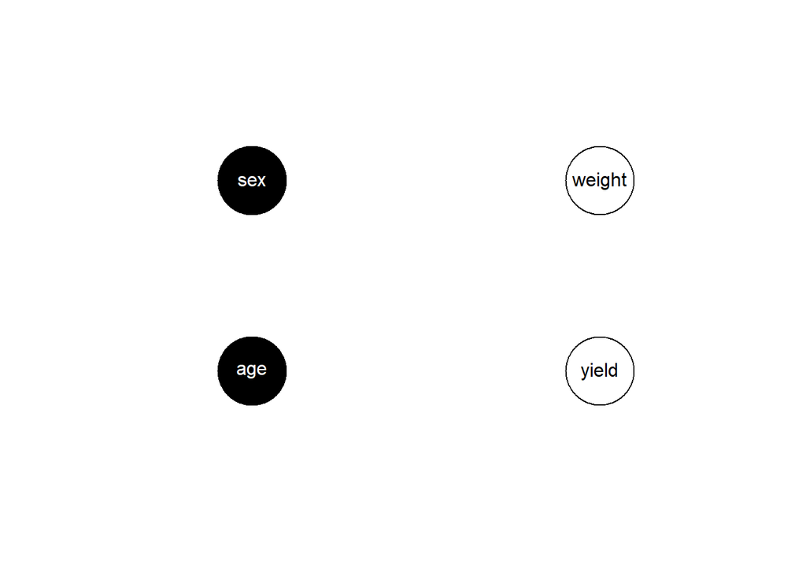

```r
plot(data.network)
```

- 學習網路

```r
prior <- jointprior(data.network)
```

```
## Imaginary sample size: 6.666667
```

```r
data.network <- getnetwork(learn(data.network, allData, prior))
```

- 尋找最佳網路

```r
theBestNetwork <- getnetwork(autosearch(data.network, allData, prior))
```

```
## [Autosearch
```

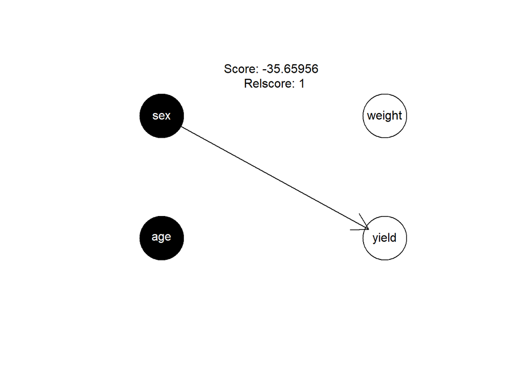

```
## (1) -35.65956 [sex][age][yield|sex][weight]
```

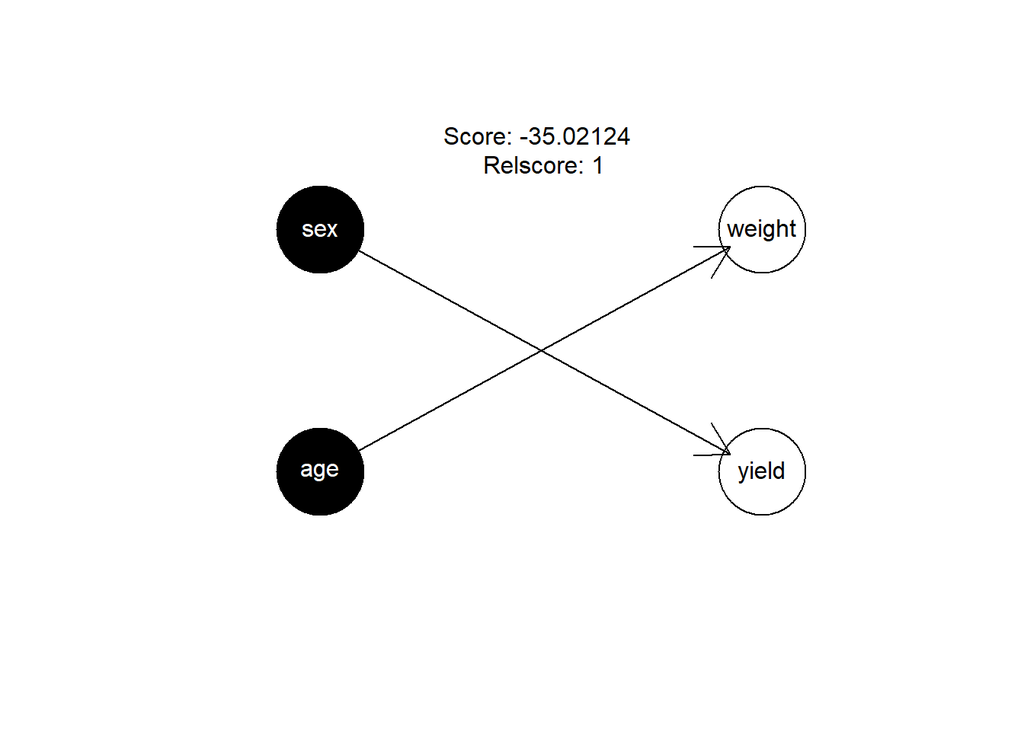

```
## (2) -35.02124 [sex][age][yield|sex][weight|age]
```

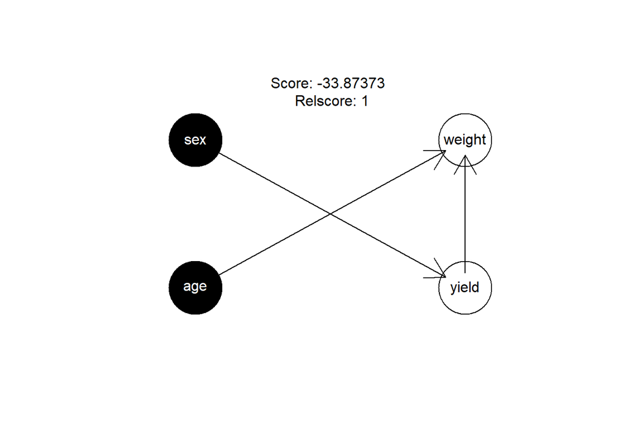

```
## (3) -33.87373 [sex][age][yield|sex][weight|age:yield]
## Total 0.5 add 0.23 rem 0.01 turn 0.03 sort 0.02 choose 0 rest 0.21 ]
```

- 顯示貝氏網路內容並儲存網路

```r
print(data.network, condposterior = TRUE)
```

```
## ##  4 ( 2 discrete+ 2 ) nodes;score= -36.5371400840653 ;relscore=
## 1    sex discrete(2)
## ------------------------------------------------------------
## Conditional Posterior: sex
## [[1]]
## [[1]]$alpha
##
##     male   female
## 8.000000 6.666667
##
## [[1]]$nu
## [1] NA
##
## [[1]]$rho
## [1] NA
##
## [[1]]$mu
## [1] NA
##
## [[1]]$phi
## [1] NA
##
## [[1]]$tau
## [1] NA
##
##
## 2    age discrete(2)
## ------------------------------------------------------------
## Conditional Posterior: age
## [[1]]
## [[1]]$alpha
##
##        1        2
## 7.333333 7.333333
##
## [[1]]$nu
## [1] NA
##
## [[1]]$rho
## [1] NA
```

[output cut: 40 more lines]

```
##
## [[1]]$nu
## [1] 6.666667
##
## [[1]]$rho
## [1] 14.66667
##
## [[1]]$mu
## [1] -0.07157472
##
## [[1]]$phi
## [1] 8.046199
##
## [[1]]$tau
## [1] 14.66667
```

```r
savenet(data.network, file("data.net"))
```

### 自動搜索網路 (autosearch)

- 準備資料

```r
data(rats)
head(rats, 10)
```

```
##    Sex Drug W1 W2
## 1    M   D1  5  6
## 2    M   D1  7  6
## 3    M   D1  9  9
## 4    M   D1  5  4
## 5    M   D2  9 12
## 6    M   D2  7  7
## 7    M   D2  7  6
## 8    M   D2  6  8
## 9    M   D3 14 11
## 10   M   D3 21 15
```

- 建構並學習網路

```r
rats.net <- network(rats)

# 計算聯合先驗機率分布
rats.prior <- jointprior(rats.net, 12)
```

```
## Imaginary sample size: 12
```

```r
# learn: 估計機率分布下的參數
# getnetwork: 依據學習後的參數修改網路
rats.net <- getnetwork(learn(rats.net, rats, rats.prior))
```

- 增加方向線

```r
# insert: add the arrow from node.2 to node.1
rats.net <- getnetwork(insert(rats.net,2,1, rats, rats.prior))

# insert: add the arrow from node.1 to node.3
rats.net <- getnetwork(insert(rats.net,1,3, rats, rats.prior))
```

- 自動搜索網路

```r
# trace: 列出搜尋結果
# removecycles: 搜索網路時，是否排除含有環(cycle)的子網路
rats.net.auto <- autosearch(rats.net, rats, rats.prior, trace = FALSE, removecycles = TRUE)
```

```
## [Autosearch (1) -170.0867 [Sex|Drug][Drug][W1|Sex:W2][W2]
## (2) -166.3658 [Sex|Drug][Drug][W1|Sex:Drug:W2][W2]
## (3) -163.5749 [Sex|Drug][Drug][W1|Drug:W2][W2]
## (4) -161.4324 [Sex|Drug][Drug][W1|Drug][W2|W1]
## (5) -160.2244 [Sex][Drug][W1|Drug][W2|W1]
## Total 0.07 add 0.02 rem 0.03 turn 0 sort 0 choose 0.02 rest 0 ]
```

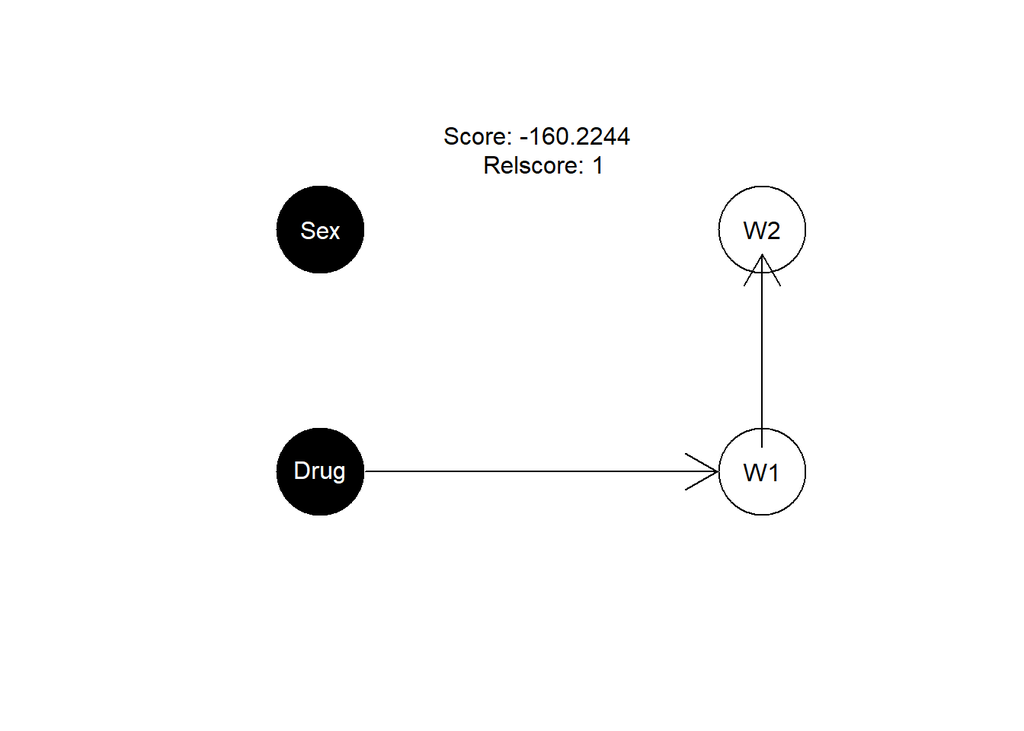

```r
plot(getnetwork(rats.net.auto))
```

- 探索式建立網路

```r
# 透過 greedy search 嘗試建立網路，以提升網路分數
rats.net.hisc <- heuristic(rats.net, rats, rats.prior, restart = 20, trace = FALSE)
```

```
## [Heuristic [Autosearch (1) -170.0867 [Sex|Drug][Drug][W1|Sex:W2][W2]
## (2) -166.3658 [Sex|Drug][Drug][W1|Sex:Drug:W2][W2]
## (3) -163.5749 [Sex|Drug][Drug][W1|Drug:W2][W2]
## (4) -161.4324 [Sex|Drug][Drug][W1|Drug][W2|W1]
## (5) -160.2244 [Sex][Drug][W1|Drug][W2|W1]
## Total 0.07 add 0.02 rem 0.02 turn 0 sort 0.01 choose 0 rest 0.02 ]
## [Perturb 0.03 ]
## [Autosearch (1) -166.4958 [Sex][Drug][W1|Drug][W2]
## (2) -160.2244 [Sex][Drug][W1|Drug][W2|W1]
## Total 0.01 add 0.01 rem 0 turn 0 sort 0 choose 0 rest 0 ]
## [Perturb 0.02 ]
## [Autosearch (1) -163.2002 [Sex][Drug][W1|Sex:Drug][W2|Sex:W1]
## (2) -160.6097 [Sex][Drug][W1|Drug][W2|Sex:W1]
## (3) -160.2244 [Sex][Drug][W1|Drug][W2|W1]
## Total 0.03 add 0 rem 0 turn 0.01 sort 0 choose 0 rest 0.02 ]
## [Perturb 0.04 ]
## [Perturb 0.02 ]
## [Autosearch (1) -171.5106 [Sex|Drug][Drug][W1|Sex:W2][W2|Sex:Drug]
## (2) -167.7897 [Sex|Drug][Drug][W1|Sex:Drug:W2][W2|Sex:Drug]
## (3) -164.9988 [Sex|Drug][Drug][W1|Drug:W2][W2|Sex:Drug]
## (4) -163.5157 [Sex|Drug][Drug][W1|Drug:W2][W2|Drug]
## (5) -162.3077 [Sex][Drug][W1|Drug:W2][W2|Drug]
## (6) -162.3077 [Sex][Drug][W1|Drug][W2|Drug:W1]
## (7) -160.2244 [Sex][Drug][W1|Drug][W2|W1]
## Total 0.03 add 0.01 rem 0.02 turn 0 sort 0 choose 0 rest 0 ]
## [Perturb 0 ]
## [Perturb 0 ]
## [Perturb 0.02 ]
## [Autosearch (1) -164.2492 [Sex][Drug|Sex][W1|Drug:W2][W2|Sex]
## (2) -161.8177 [Sex][Drug|Sex][W1|Drug][W2|Sex:W1]
## (3) -160.6097 [Sex][Drug][W1|Drug][W2|Sex:W1]
## (4) -160.2244 [Sex][Drug][W1|Drug][W2|W1]
## Total 0 add 0 rem 0 turn 0 sort 0 choose 0 rest 0 ]
## [Perturb 0.02 ]
## [Autosearch (1) -170.0275 [Sex][Drug|Sex][W1|Sex:W2][W2|Drug]
## (2) -166.3066 [Sex][Drug|Sex][W1|Sex:Drug:W2][W2|Drug]
## (3) -163.5157 [Sex][Drug|Sex][W1|Drug:W2][W2|Drug]
## (4) -162.3077 [Sex][Drug][W1|Drug:W2][W2|Drug]
## (5) -162.3077 [Sex][Drug][W1|Drug][W2|Drug:W1]
## (6) -160.2244 [Sex][Drug][W1|Drug][W2|W1]
```

[output cut: 10 more lines]

```
## (4) -160.2244 [Sex][Drug][W1|Drug][W2|W1]
## Total 0.02 add 0 rem 0 turn 0.02 sort 0 choose 0 rest 0 ]
## [Perturb 0 ]
## [Perturb 0.02 ]
## [Perturb 0 ]
## [Perturb 0 ]
## [Perturb 0 ]
## [Perturb 0 ]
## [Autosearch (1) -164.023 [Sex][Drug|Sex][W1|Sex:Drug][W2|W1]
## (2) -161.4324 [Sex][Drug|Sex][W1|Drug][W2|W1]
## (3) -160.2244 [Sex][Drug][W1|Drug][W2|W1]
## Total 0.01 add 0 rem 0 turn 0 sort 0.01 choose 0 rest 0 ]
## Tried 120 out of approx. 144 networks
## 0.46 ]
## Perturb: 0.19 ,Autosearch: 0.28 ,Unique: 0
```

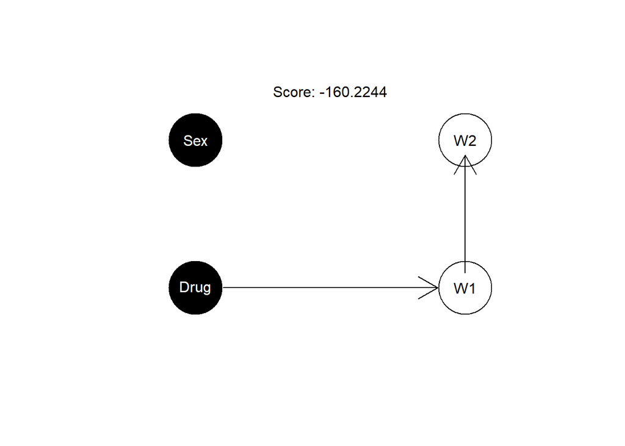

```r
plot(getnetwork(rats.net.hisc))
```

- 顯示網路建立狀況

```r
print(modelstring(getnetwork(rats.net.hisc)))
```

```
## [1] "[Sex][Drug][W1|Drug][W2|W1]"
```

### 網路族分析

- 繪出網路族譜

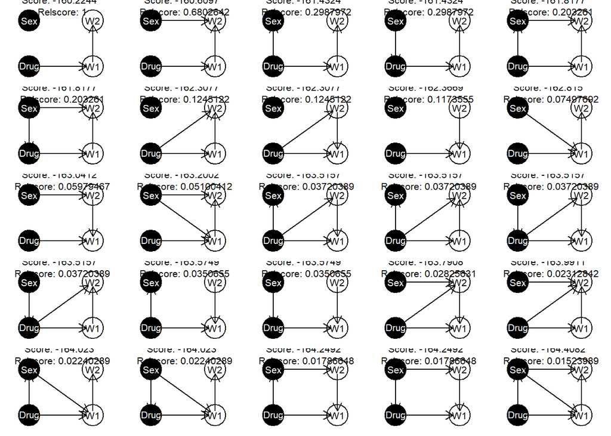

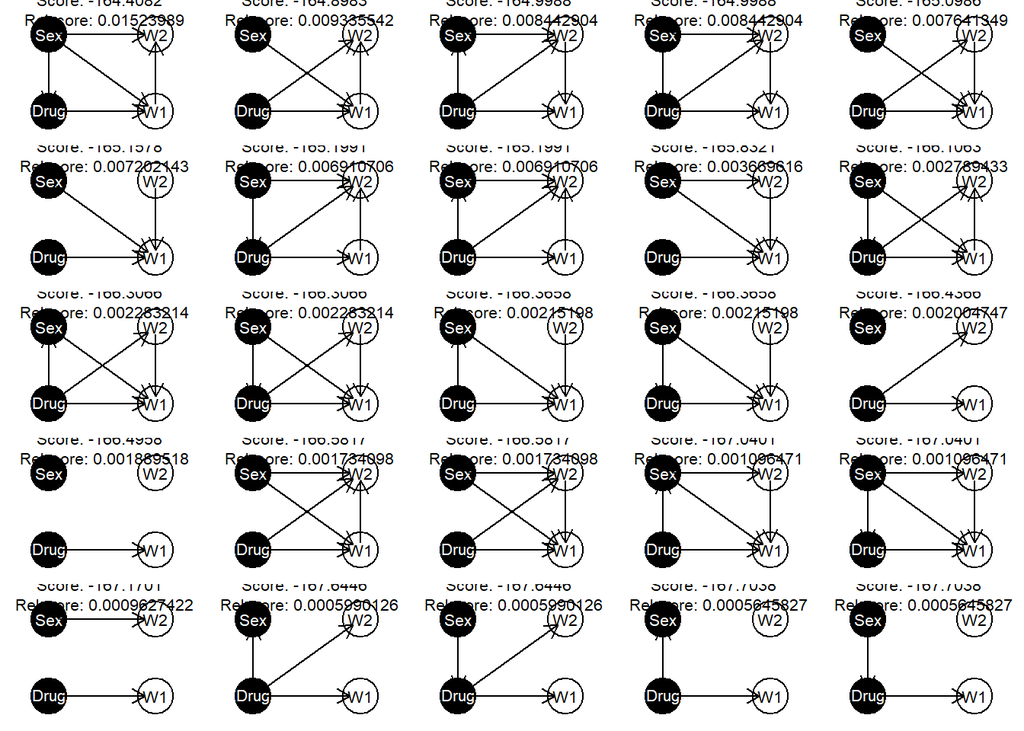

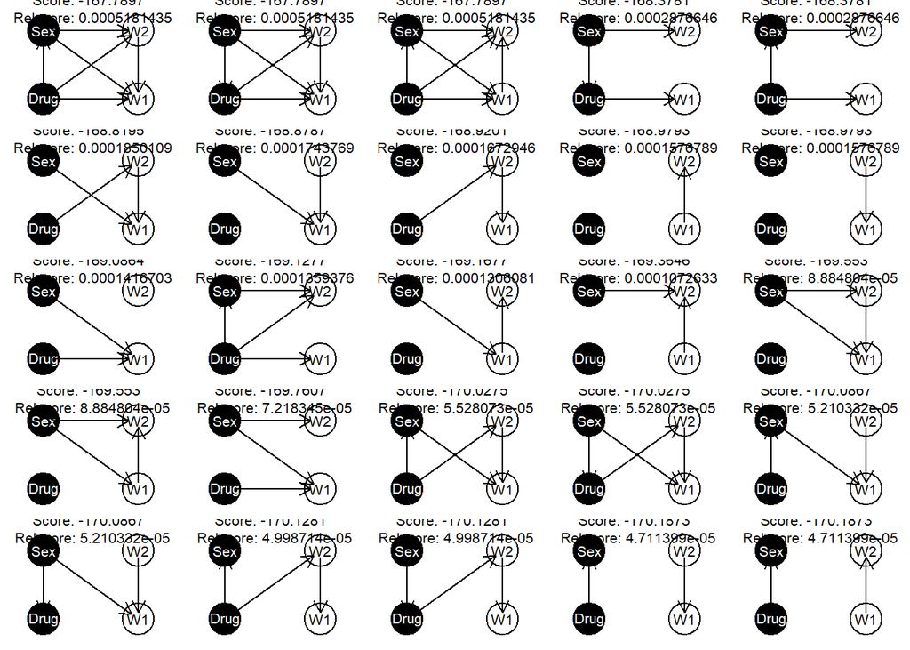

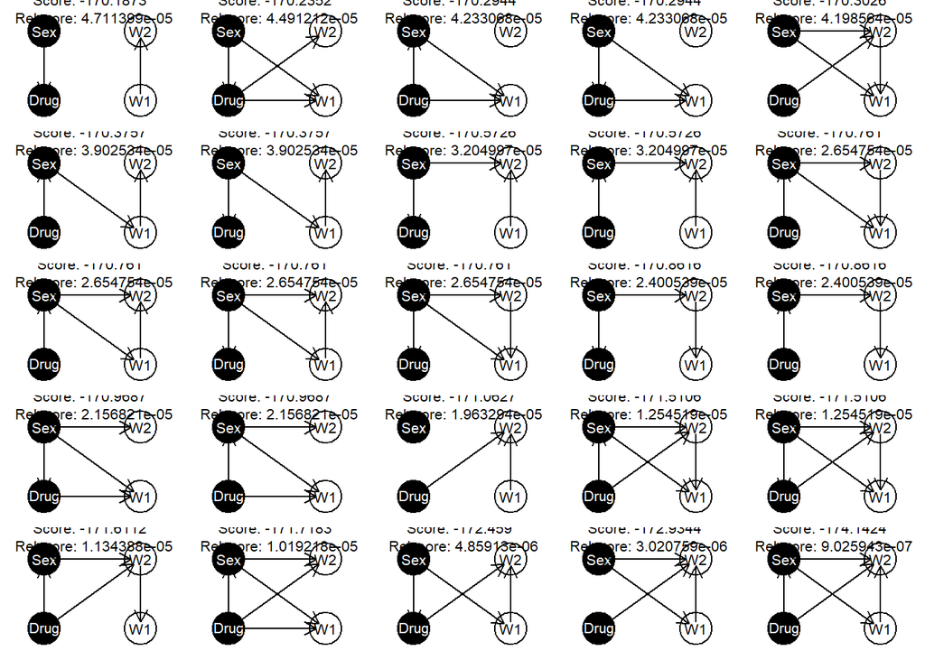

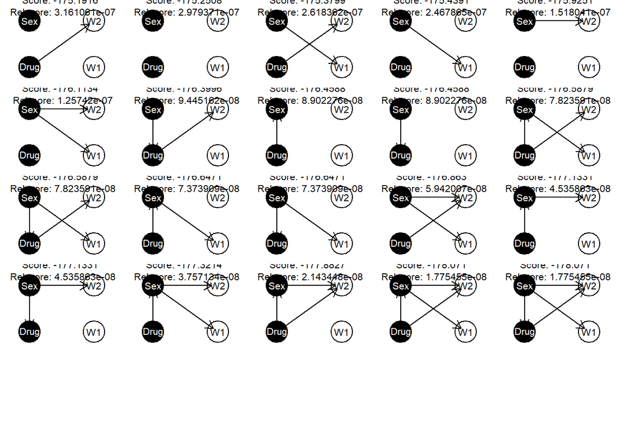

```r
plot(makenw(gettable(rats.net.hisc), rats.net))
```

- 對網路族分析

```r
nwfsort(makenw(gettable(rats.net.hisc), rats.net))
```

```
## Discrete:  Sex(2),Drug(3)
## Continuous:W1,W2
##   log(Score) |Relscore   |Network
## ------------------------------------------------------------
## 1. -160.2244 1       [Sex][Drug][W1|Drug][W2|W1]
## 2. -160.6097 0.6802642   [Sex][Drug][W1|Drug][W2|SexW1]
## 3. -161.4324 0.2987972   [Sex|Drug][Drug][W1|Drug][W2|W1]
## 4. -161.4324 0.2987972   [Sex][Drug|Sex][W1|Drug][W2|W1]
## 5. -161.8177 0.203261    [Sex|Drug][Drug][W1|Drug][W2|SexW1]
## 6. -161.8177 0.203261    [Sex][Drug|Sex][W1|Drug][W2|SexW1]
## 7. -162.3077 0.1245122   [Sex][Drug][W1|Drug][W2|DrugW1]
## 8. -162.3077 0.1245122   [Sex][Drug][W1|DrugW2][W2|Drug]
## 9. -162.3669 0.1173555   [Sex][Drug][W1|DrugW2][W2]
## 10. -162.815 0.07497692  [Sex][Drug][W1|SexDrug][W2|W1]
## 11. -163.0412    0.05979467  [Sex][Drug][W1|DrugW2][W2|Sex]
## 12. -163.2002    0.05100412  [Sex][Drug][W1|SexDrug][W2|SexW1]
## 13. -163.5157    0.03720389  [Sex|Drug][Drug][W1|DrugW2][W2|Drug]
## 14. -163.5157    0.03720389  [Sex|Drug][Drug][W1|Drug][W2|DrugW1]
## 15. -163.5157    0.03720389  [Sex][Drug|Sex][W1|DrugW2][W2|Drug]
## 16. -163.5157    0.03720389  [Sex][Drug|Sex][W1|Drug][W2|DrugW1]
## 17. -163.5749    0.0350655   [Sex|Drug][Drug][W1|DrugW2][W2]
## 18. -163.5749    0.0350655   [Sex][Drug|Sex][W1|DrugW2][W2]
## 19. -163.7908    0.02825631  [Sex][Drug][W1|DrugW2][W2|SexDrug]
## 20. -163.9911    0.02312842  [Sex][Drug][W1|Drug][W2|SexDrugW1]
## 21. -164.023 0.02240289  [Sex|Drug][Drug][W1|SexDrug][W2|W1]
## 22. -164.023 0.02240289  [Sex][Drug|Sex][W1|SexDrug][W2|W1]
## 23. -164.2492    0.01786648  [Sex|Drug][Drug][W1|DrugW2][W2|Sex]
## 24. -164.2492    0.01786648  [Sex][Drug|Sex][W1|DrugW2][W2|Sex]
## 25. -164.4082    0.01523989  [Sex|Drug][Drug][W1|SexDrug][W2|SexW1]
## 26. -164.4082    0.01523989  [Sex][Drug|Sex][W1|SexDrug][W2|SexW1]
## 27. -164.8983    0.009335542 [Sex][Drug][W1|SexDrug][W2|DrugW1]
## 28. -164.9988    0.008442904 [Sex|Drug][Drug][W1|DrugW2][W2|SexDrug]
## 29. -164.9988    0.008442904 [Sex][Drug|Sex][W1|DrugW2][W2|SexDrug]
## 30. -165.0986    0.007641349 [Sex][Drug][W1|SexDrugW2][W2|Drug]
## 31. -165.1578    0.007202143 [Sex][Drug][W1|SexDrugW2][W2]
## 32. -165.1991    0.006910706 [Sex][Drug|Sex][W1|Drug][W2|SexDrugW1]
## 33. -165.1991    0.006910706 [Sex|Drug][Drug][W1|Drug][W2|SexDrugW1]
## 34. -165.8321    0.003669616 [Sex][Drug][W1|SexDrugW2][W2|Sex]
## 35. -166.1063    0.002789433 [Sex][Drug|Sex][W1|SexDrug][W2|DrugW1]
## 36. -166.3066    0.002283214 [Sex|Drug][Drug][W1|SexDrugW2][W2|Drug]
```

[output cut: 69 more lines]

```
## 106. -176.1134   1.25742e-07 [Sex][Drug][W1|Sex][W2|Sex]
## 107. -176.3996   9.445162e-08    [Sex][Drug|Sex][W1][W2|Drug]
## 108. -176.4588   8.902276e-08    [Sex|Drug][Drug][W1][W2]
## 109. -176.4588   8.902276e-08    [Sex][Drug|Sex][W1][W2]
## 110. -176.5879   7.823591e-08    [Sex|Drug][Drug][W1|Sex][W2|Drug]
## 111. -176.5879   7.823591e-08    [Sex][Drug|Sex][W1|Sex][W2|Drug]
## 112. -176.6471   7.373909e-08    [Sex|Drug][Drug][W1|Sex][W2]
## 113. -176.6471   7.373909e-08    [Sex][Drug|Sex][W1|Sex][W2]
## 114. -176.863    5.942007e-08    [Sex][Drug][W1|Sex][W2|SexDrug]
## 115. -177.1331   4.535863e-08    [Sex|Drug][Drug][W1][W2|Sex]
## 116. -177.1331   4.535863e-08    [Sex][Drug|Sex][W1][W2|Sex]
## 117. -177.3214   3.757134e-08    [Sex|Drug][Drug][W1|Sex][W2|Sex]
## 118. -177.8827   2.143448e-08    [Sex|Drug][Drug][W1][W2|SexDrug]
## 119. -178.071    1.775455e-08    [Sex|Drug][Drug][W1|Sex][W2|SexDrug]
## 120. -178.071    1.775455e-08    [Sex][Drug|Sex][W1|Sex][W2|SexDrug]
```